# 01_QC

Author

Qian Hui TAN

Published

October 5, 2023

# 1 01_QC

In this notebook, we perform quality control on bulk RNA-seq data obtained from Drosophila embryos. The various conditions are summarized below:

| RNA-seq label | Experimental label | Description |
| --- | --- | --- |
| Ctrl | Control | Embryos from control flies. |
| W4_OE | UAS-Wnt4 | Embryos in which Wnt4 is over-expressed. |
| O1_OE | UAS-Otk1 | Embryos in which Otk1 is over-expressed. |
| O1W4_OE | UAS-Otk1, UAS-Wnt4 | Embryos in which Otk1 and Wnt4 are both over-expressed. |
| O2_KO | Otk2 RNAi | Embryos in which Otk2 is downregulated. |
| W4_KO | Wnt4 RNAi | Embryos in which Wnt4 is downregulated. |
| O1_KO | Otk1 RNAi | Embryos in which Otk1 is downregulated. |
| O1W4_KO | Otk1, Wnt4 RNAi | Embryos in which Otk1 and Wnt4 are both downregulated. |
| O2W4_KO | Otk2, Wnt4 RNAi | Embryos in which Otk2 and Wnt4 are both downregulated. |
| O1O2_KO | Otk1, Otk2 RNAi | Embryos in which Otk1 and Otk2 are both downregulated. |

# 2 Setup

```r
## If output directory doesn't exist, create it
if(!dir.exists("../output")){
    dir.create("../output")
  }

if(!dir.exists("../output/01_QC")){
    dir.create("../output/01_QC")
  }

output_dir <- "../output/01_QC/"


manual_colors = c("darkgrey",
                   "#1f78b4", "#33a02c","#6600FF","#e31a1c",

                   "#a6cee3", "#b2df8a","#CC99FF", "lightpink",
                   "coral")
```

```r
suppressPackageStartupMessages({
    library(dplyr)
    library(readr)
    library(tidyr)
    library(ggplot2)
    library(janitor)
    library(GEOquery)
    library(DESeq2)
    library(reshape2) # melt function
    library(biomaRt)
    library(GenomicFeatures)
    library(scales)
    library(ggrepel)
    library(pheatmap)
    library(viridis)
    library(lubridate)
    library(DT)
})

source("../../scripts/R/qc_functions.R")
source("../../scripts/R/ma_plot_function.R")
```

```r
# Generic theme
th <- theme(
         plot.title = element_text(size = 15),
         plot.subtitle = element_text(size = 12),
         axis.title.x = element_blank(),
         axis.title.y = element_blank())

# PCA theme
pca_th <- theme(plot.title = element_text(size = 15),
         axis.title.x = element_text(size = 10),
         axis.title.y = element_text(size = 10),
         axis.text.x = element_text(size = 10),
         axis.text.y = element_text(size = 10))
```

We first create gene-level annotations:

```r
# Create transcript annotations from the Drosophila genome
fg.gtf.db <- makeTxDbFromGFF("../../data/04_annotations/Drosophila_melanogaster.BDGP6.22.97.chr.gtf", format = "gtf")

# Extract genes from the transcript annotation.
ensembl.genes = genes(fg.gtf.db)

## -- Retrieving biomaRt annotations -- ##

# For each ensembl gene in the drosophila genome, we retrieve additional
# information such as the gene biotype, gene name, entrez id. These will be
# useful for downstream analysis steps.

# Set fly
fly = useEnsembl(
  biomart = "ENSEMBL_MART_ENSEMBL",
  host = "https://asia.ensembl.org",
  dataset = "dmelanogaster_gene_ensembl",
  version = "97"
)

# For each gene, retrieve the following annotations from biomaRt
bm.annotations = getBM(
  attributes = c("ensembl_gene_id",# FBgn, highly specific identifier"
                 "external_gene_name", # normal gene name
                 "gene_biotype",
                 "go_id", # go term accession
                 "name_1006", # go term name,
                 "entrezgene_id",# entrezid for pathway
                 "description"
  ),
  mart = fly,
  filters = "ensembl_gene_id",
  values = ensembl.genes$gene_id,
  uniqueRows = TRUE
)

# Checking bm.annotations
head(bm.annotations)

## -- Creating the object -- ##
# Create ensembl.genes object
ensembl.genes$ensembl_gene_id = bm.annotations$ensembl_gene_id[
  match(ensembl.genes$gene_id, bm.annotations$ensembl_gene_id)]
ensembl.genes$external_gene_name = bm.annotations$external_gene_name[
  match(ensembl.genes$gene_id, bm.annotations$ensembl_gene_id)]
ensembl.genes$gene_biotype = bm.annotations$gene_biotype[
  match(ensembl.genes$gene_id,bm.annotations$ensembl_gene_id)]
ensembl.genes$go_id = bm.annotations$go_id[
  match(ensembl.genes$gene_id,bm.annotations$ensembl_gene_id)]
ensembl.genes$name_1006 = bm.annotations$name_1006[
  match(ensembl.genes$gene_id, bm.annotations$ensembl_gene_id)]
ensembl.genes$entrezgene_id = bm.annotations$entrezgene_id[
  match(ensembl.genes$gene_id, bm.annotations$ensembl_gene_id)]

head(ensembl.genes)

# Save the output
saveRDS(ensembl.genes, file = "../output/01_QC/ensembl_genes.RDS")
```

```r
ensembl.genes <- readRDS("../output/01_QC/ensembl_genes.RDS")
```

# 3 Preparing objects for DESeq

## 3.1 Metadata wrangling

```r
experimental_metadata = na.omit(read.delim("../../data/03_metadata/metadata.csv",
                                           sep = ",",
                                   header = TRUE, stringsAsFactors = FALSE,
                                   blank.lines.skip = TRUE))

# Remove empty row(s), if any
experimental_metadata <- experimental_metadata[!experimental_metadata$condition == "", ]

dim(experimental_metadata)
```

```
[1] 20  4
```

```r
experimental_metadata
```

|  | sample_id | condition | batch | description |
| --- | --- | --- | --- | --- |
| 1 | Ctrl_1 | Ctrl | 1 | Embryos from wild-type flies. |
| 2 | Ctrl_2 | Ctrl | 2 | Embryos from wild-type flies. |
| 4 | W4_OE_1 | W4_OE | 1 | Embryos in which Wnt4 is over-expressed. |
| 5 | W4_OE_2 | W4_OE | 2 | Embryos in which Wnt4 is over-expressed. |
| 7 | O1_OE_1 | O1_OE | 1 | Embryos in which Otk1 is over-expressed. |
| 8 | O1_OE_2 | O1_OE | 2 | Embryos in which Otk1 is over-expressed. |
| 10 | O1W4_OE_1 | O1W4_OE | 1 | Embryos in which Otk1 and Wnt4 are both over-expressed. |
| 11 | O1W4_OE_2 | O1W4_OE | 2 | Embryos in which Otk1 and Wnt4 are both over-expressed. |
| 13 | O2_KO_1 | O2_KO | 1 | Embryos in which Otk2 is downregulated. |
| 14 | O2_KO_2 | O2_KO | 2 | Embryos in which Otk2 is downregulated. |
| 16 | W4_KO_1 | W4_KO | 1 | Embryos in which Wnt4 is downregulated. |
| 17 | W4_KO_2 | W4_KO | 2 | Embryos in which Wnt4 is downregulated. |
| 19 | O1_KO_1 | O1_KO | 1 | Embryos in which Otk1 is downregulated. |
| 20 | O1_KO_2 | O1_KO | 2 | Embryos in which Otk1 is downregulated. |
| 22 | O1W4_KO_1 | O1W4_KO | 1 | Embryos in which Otk1 and Wnt4 are both downregulated. |
| 23 | O1W4_KO_2 | O1W4_KO | 2 | Embryos in which Otk1 and Wnt4 are both downregulated. |
| 25 | O2W4_KO_1 | O2W4_KO | 1 | Embryos in which Otk2 and Wnt4 are both downregulated. |
| 26 | O2W4_KO_2 | O2W4_KO | 2 | Embryos in which Otk2 and Wnt4 are both downregulated. |
| 28 | O1O2_KO_1 | O1O2_KO | 1 | Embryos in which Otk1 and Otk2 are both downregulated. |
| 29 | O1O2_KO_2 | O1O2_KO | 2 | Embryos in which Otk1 and Otk2 are both downregulated. |

## 3.2 Creating the data matrix

```r
# Create a matrix of the data (nrow can be obtained by calling wc -l *.genes.results in terminal; note -1 for header)
data = matrix(0, ncol = length(experimental_metadata$sample_id),
              nrow = 17714)
colnames(data) = experimental_metadata$sample_id

for (i in experimental_metadata$sample_id){
 data[ ,i] = read.table(paste("../../data/02_aligned/02_RSEM/", i, ".genes.results",
                              sep = ""),
                         header = TRUE)$expected_count
  row.names(data) = read.table(paste("../../data/02_aligned/02_RSEM/", i, ".genes.results",
                                     sep=""),
                               header=TRUE)$gene_id
}


# DESeq needs read counts to be integers
data_mat = apply(round(data), c(1,2), as.integer)

#head(data_mat)
```

## 3.3 Create DESeq object

```r
# Create DESeq object
dds = DESeqDataSetFromMatrix(data_mat, experimental_metadata, ~ condition)
colnames(dds) = colnames(data_mat)

#head(colData(dds)) # Check that condition matches sample
```

```r
#Estimates the size factors using the "median ratio method" described by Equation 5 in Anders and Huber (2010)
dds <- estimateSizeFactors(dds)
#This function obtains dispersion estimates for a count data set
dds <- estimateDispersions(dds)
#This function transforms the count data to the log2 scale in a way which minimizes differences between samples for rows with small counts
rld <- rlog(dds, blind = TRUE) # use blind = TRUE for QC
```

```r
data_mat_nonzero = data_mat[rowSums(data_mat) > 0, ] # Remove non-zero rows
```

## 3.4 How many non-zero rows?

```r
nrow(data_mat)
```

```
[1] 17714
```

How many genes are expressed (at least 1 read in at least 1 sample)?

```r
nrow(data_mat_nonzero)
```

```
[1] 15684
```

What percentage is this?

```r
nrow(data_mat_nonzero)/nrow(data_mat) * 100
```

```
[1] 88.54014
```

89% of all rows are nonzero.

# 4 DESeq QC

## 4.1 Setup colors

```r
sample_order = colData(dds)$sample_id
condition_order <- c("Ctrl",
                     "W4_OE", "O1_OE", "O1W4_OE", "O2_KO",
                     "W4_KO", "O1_KO", "O1W4_KO", "O2W4_KO", "O1O2_KO")

col_colors <- c("darkgrey", #Ctrls
                '#00362d', '#3a6f60', '#80ac95', '#ceebcb', #OEs
                '#552200', '#834a25', '#b0764f', '#daa680', '#ffdab8' #KOs
                )
```

## 4.2 Dispersion estimates

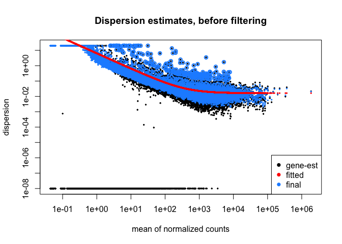

```r
## Plot dispersion estimates
plotDispEsts(dds, main = "Dispersion estimates, before filtering")
```

## 4.3 QC - number of detected genes

Examining our dataset:

```r
dds
```

```
class: DESeqDataSet
dim: 17714 20
metadata(1): version
assays(2): counts mu
rownames(17714): FBgn0000003 FBgn0000008 ... FBgn0286213 FBgn0286222
rowData names(10): baseMean baseVar ... dispOutlier dispMAP
colnames(20): Ctrl_1 Ctrl_2 ... O1O2_KO_1 O1O2_KO_2
colData names(5): sample_id condition batch description sizeFactor
```

We plot a few key metrics to check our data quality:

```r
plt_title = "Before Filtering"
```

**Read counts per sample**

```r
total_counts <- as.data.frame(colSums(counts(dds)))
colnames(total_counts) <- "total_counts"
total_counts$name = rownames(total_counts)
# Convert to factor to preserve order
total_counts$name <- factor(total_counts$name,
                            levels = rev(experimental_metadata$sample_id))
```

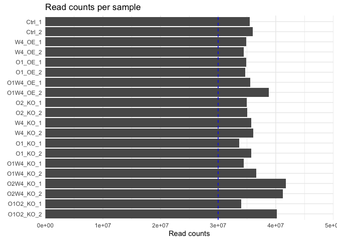

```r
# Plot
ggplot(total_counts, aes(x = name, y = total_counts)) +
    geom_bar(stat = "identity") +
    scale_y_continuous("Read counts",
                       limits = c(0, 5e7),
                       expand = c(0, 0),
                       breaks = seq(0, 5e7, 1e7)) +
    geom_hline(yintercept = 3e7, color = "blue", linetype = "dashed") +
    labs(title = "Read counts per sample",
         x = element_blank()) +
    theme_minimal() +
    coord_flip()
```

**Number of genes detected per sample**

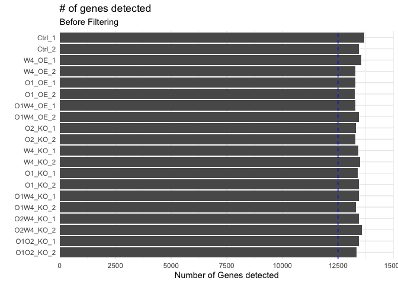

```r
detected = apply(counts(dds), 2, function(col) sum(col > 0 ))
detected = as.data.frame(detected)
detected$name = row.names(detected)
detected$name = factor(detected$name, rev(experimental_metadata$sample_id))

ggplot(detected, aes(x=name, y=detected)) +
                 geom_bar(stat="identity") +
                 theme_minimal() +
                 coord_flip() +
                 scale_y_continuous("Number of Genes detected", expand=c(0,0),
                                    breaks = seq(0, 15000, 2500),
                                    limits = c(0, 1.5e4)
                                    ) +
                 scale_x_discrete("") +
                 labs(title = "# of genes detected",
                     subtitle = plt_title) +
                 geom_hline(yintercept = 12500, color = "blue", linetype = "dashed")
```

**Size factors**

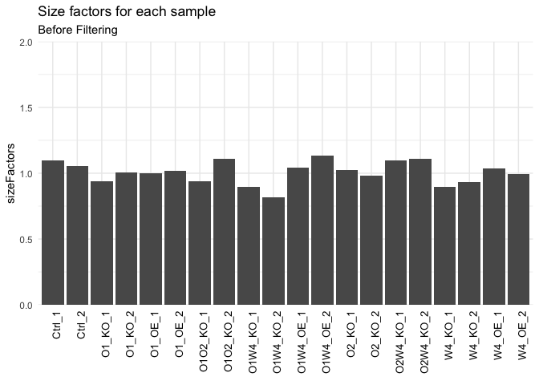

```r
df = data.frame(sample_id = names(sizeFactors(dds)),
                sizeFactors = sizeFactors(dds))

ggplot(df, aes(x = sample_id, y = sizeFactors)) +
    geom_bar(stat="identity") +
    scale_y_continuous(limits = c(0,2), expand = c(0,0)) +
    labs(title = "Size factors for each sample",
         subtitle = plt_title,
         x = element_blank()) +
    theme_minimal() +
    theme(axis.text.x = element_text(angle = 90, hjust=1,
                                     colour="black", size = 10))
```

**Normalized counts (boxplot)**

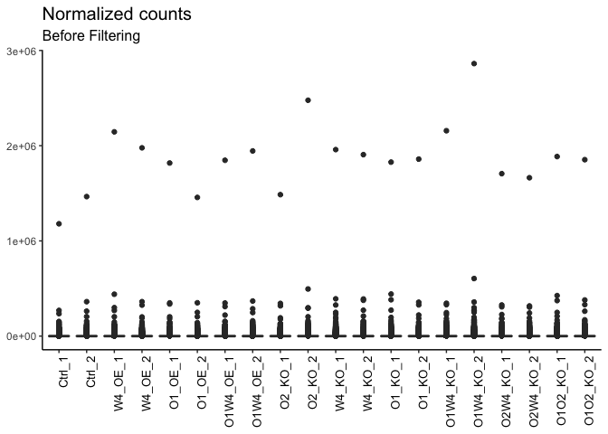

```r
nc = counts(dds, normalized=TRUE)
nc.melt = melt(nc)

ggplot(nc.melt, aes(x=Var2, y=value)) +
    geom_boxplot() +
    theme_classic() +
    theme(axis.text.x = element_text(angle = 90, colour="black", hjust = 1,
                                     size = 10)) +
    scale_x_discrete("Sample") +
    scale_y_continuous("Normalised counts") +
    labs(title = "Normalized counts",
        subtitle = plt_title) +
    th
```

```r
nc.threshold = 1e6
test = apply(nc, 1, function(x){ any(x > nc.threshold) })
```

The genes with normalized counts greater than 10^{6} are:

```r
above_threshold <- as.data.frame(ensembl.genes[names(test[test])])

above_threshold[ ,colnames(above_threshold) %in%
                   c("gene_id", "gene_biotype", "external_gene_name")]
```

|  | gene_id | external_gene_name | gene_biotype |
| --- | --- | --- | --- |
| FBgn0013686 | FBgn0013686 | mt:lrRNA | rRNA |

That’s an rRNA.

Plotting the rRNA graph:

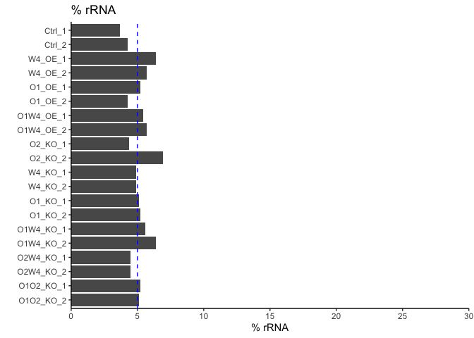

```r
rrna.genes = names(ensembl.genes[ensembl.genes$gene_biotype %in% c("Mt_rRNA", "rRNA")])
percentage.of.rrna = (colSums(counts(dds[ rownames(counts(dds)) %in% rrna.genes])) / colSums(counts(dds))) * 100

percentage.of.rrna = as.data.frame(percentage.of.rrna)
percentage.of.rrna$name = rownames(percentage.of.rrna)
percentage.of.rrna$name = factor(percentage.of.rrna$name,
                                 rev(experimental_metadata$sample_id))

ggplot(percentage.of.rrna,
       aes(x = name, y = percentage.of.rrna)) +
        geom_bar(stat="identity") +
        geom_hline(yintercept = 5, color = "blue", linetype = "dashed") +
        theme_classic() +
        coord_flip() +
        scale_y_continuous("% rRNA",
                           expand=c(0,0), limits = c(0, 30), breaks = seq(0, 30, 5)) +
        labs(title = "% rRNA", x = "")
```

Checking summary statistics for rRNA:

```r
summary(percentage.of.rrna$percentage.of.rrna)
```

```
   Min. 1st Qu.  Median    Mean 3rd Qu.    Max.
  3.658   4.487   5.164   5.167   5.610   6.921
```

There’s some rRNA, but they are all less than 7%. That’s good - it indicates that most reads still belong to non-rRNA reads. Regardless, we will filter out these rRNA reads from our analysis later.

**Proportions of gene biotypes**

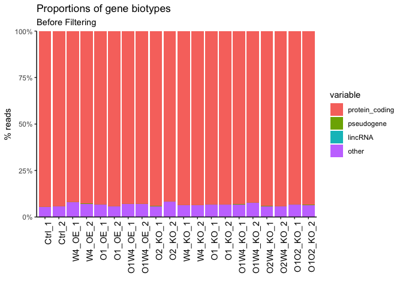

```r
pc = ensembl.genes$gene_id[ensembl.genes$gene_biotype == "protein_coding"]
pg = ensembl.genes$gene_id[ensembl.genes$gene_biotype %in% unique(ensembl.genes$gene_biotype)[grep("pseudogene", unique(ensembl.genes$gene_biotype))]]
lc = ensembl.genes$gene_id[ensembl.genes$gene_biotype == "lincRNA"]

totalcounts.pc = colSums(counts(dds)[rownames(counts(dds)) %in% pc,])
totalcounts.pg = colSums(counts(dds)[rownames(counts(dds)) %in% pg,])
totalcounts.lc = colSums(counts(dds)[rownames(counts(dds)) %in% lc,])

totalcounts.other = colSums(counts(dds)[!(rownames(counts(dds)) %in% c(lc,pc,pg)),])

counts.by.biotype = data.frame(name = names(totalcounts.pc),
                         protein_coding = totalcounts.pc,
                         pseudogene = totalcounts.pg,
                         lincRNA = totalcounts.lc,
                         other = totalcounts.other

                         )


counts.by.biotype = as.data.frame(t(apply(counts.by.biotype[,2:5], 1, function(x){ 100 * (x / sum(x)) }) ))
counts.by.biotype$name = names(totalcounts.pc)

counts.by.biotype.melt = melt(counts.by.biotype)
counts.by.biotype.melt$name = factor(counts.by.biotype.melt$name,
                                     levels = experimental_metadata$sample_id)


ggplot(counts.by.biotype.melt, aes(x=name, y=value, fill=variable)) +
    geom_bar(stat="identity") +
    theme_classic() +
    scale_x_discrete("") +
    scale_y_continuous("% reads", labels = dollar_format(suffix = "%", prefix = ""),
                       expand=c(0,0)) +
    theme(axis.text.x = element_text(angle = 90, colour="black", #family="Arial",
                                     hjust = 1, size = 11)) +
    labs(title = "Proportions of gene biotypes",
        subtitle = plt_title)
```

Most genes are protein-coding, as expected.

## 4.4 QC - clustering

We perform 3 types of Quality Control to assess our DESeq dataset:

- Correlation matrix heatmap
- Hierarchical clustering
- PCA

**Correlation matrix heatmap**

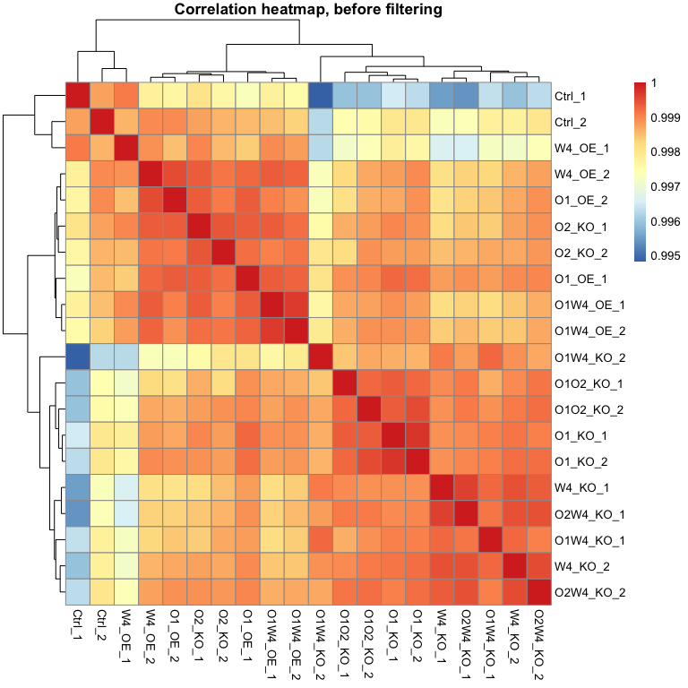

```r
### Extract the rld matrix from the object
rld_mat <- assay(rld)
### Compute pairwise correlation values
rld_cor <- cor(rld_mat)
### Plot heatmap
pheatmap(rld_cor, main = "Correlation heatmap, before filtering")
```

**Hierarchical clustering**

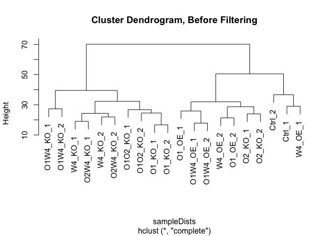

```r
sampleDists <- dist(t(assay(rld)))
plot(hclust(sampleDists), main = paste0("Cluster Dendrogram, ", plt_title))
```

**PCA**

```r
source("../../scripts/R/qc_functions.R")
```

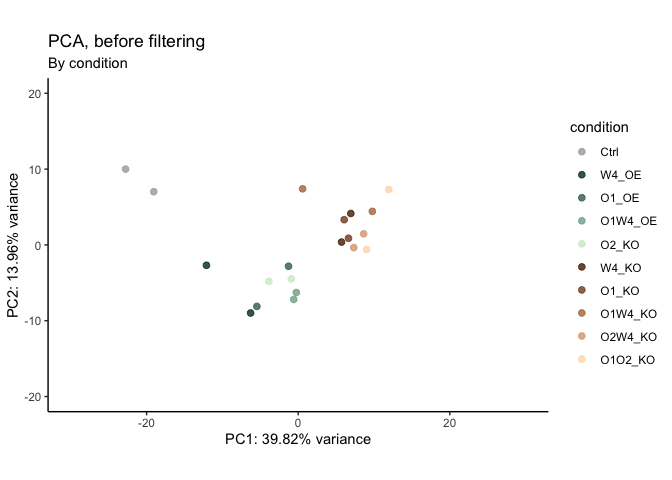

```r
intgroup = "condition"
intgroup_order = unique(experimental_metadata$condition)

pca_xlim <- c(-30, 30)
pca_ylim <- c(-20, 20)


pca_plot <- make_pca(rld, intgroup = "condition",
         xlimits = pca_xlim,
         ylimits = pca_ylim,
         manual_colors = col_colors,
         title = "PCA, before filtering",
         rearrange_intgroup = TRUE,
         intgroup_order = intgroup_order)
pca_plot
```

**PCA, labelled**

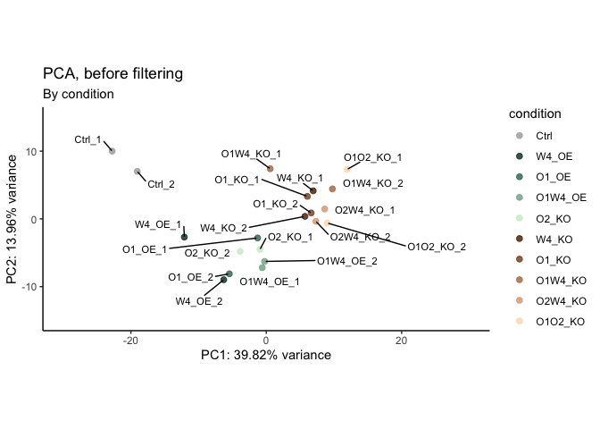

```r
make_pca(rld, intgroup = "condition", label = TRUE,
         manual_colors = col_colors,
         title = "PCA, before filtering",
         rearrange_intgroup = TRUE,
         intgroup_order = intgroup_order)
```

**PCA, by size factor**

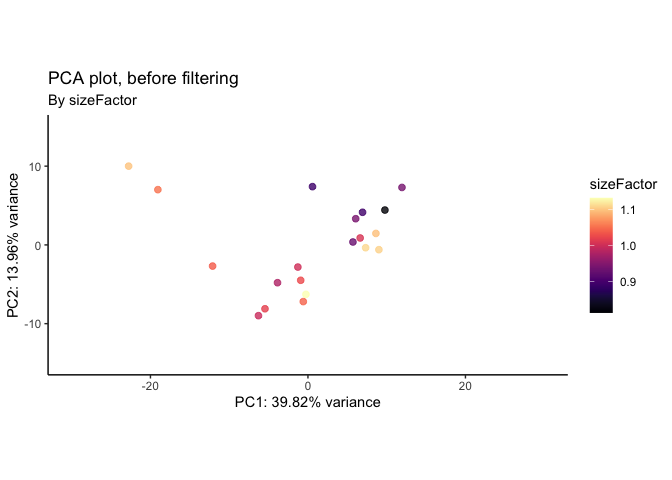

```r
make_pca(rld, intgroup = "sizeFactor",
         title = "PCA plot, before filtering") +
  scale_color_viridis(option = "A")
```

All our key metrics look good. Read counts per sample, number of genes per sample are all high, and relatively similar across all samples. Most genes are protein-coding, as expected. Data is of high quality.

# 5 Remove rRNA and mitochondrial genome

We remove all genes that map to rRNA, as well as the mitochondrial chromosome before we proceed with downstream analysis.

```r
plt_title = "after removing rRNA and mitochondrial genome"
```

Checking MT chromosome intact:

```r
in_dds = ensembl.genes[match(rownames(counts(dds)), ensembl.genes$gene_id), ]
table(seqnames(in_dds))
```

```
chr2L chr2R chr3L chr3R  chr4  chrX  chrY  chrM
 3496  3624  3460  4199   111  2673   113    38
```

Remove MT chromosome, rerun DESeq:

```r
# Remove mitochondrial genome
mit_genes <- ensembl.genes[seqnames(ensembl.genes) %in% "chrM", ]$gene_id
length(mit_genes)
```

```
[1] 38
```

```r
dds_rm_mit <- dds[!rownames(counts(dds)) %in% mit_genes, ]

# Remove rRNA
dds_filt = dds_rm_mit[!(row.names(counts(dds_rm_mit)) %in%
                   ensembl.genes$gene_id[ensembl.genes$gene_biotype %in%
                                           c("rRNA", "snoRNA", "snRNA", "Mt_rRNA")]), ]
dds_filt = dds_filt[rowSums(counts(dds_filt)) > 0, ]

# Re-estimate dispersions
dds_filt <- estimateSizeFactors(dds_filt)
dds_filt <- estimateDispersions(dds_filt)
```

```
found already estimated dispersions, replacing these
```

```r
rld_filt <- rlog(dds, blind = TRUE) # use blind = TRUE for QC
```

Check that mitochondrial genome has been removed:

```r
in_dds = ensembl.genes[match(rownames(counts(dds_filt)), ensembl.genes$gene_id), ]
table(seqnames(in_dds))
```

```
chr2L chr2R chr3L chr3R  chr4  chrX  chrY  chrM
 2960  3139  3138  3798   107  2434    79     0
```

## 5.1 Check rRNA removed

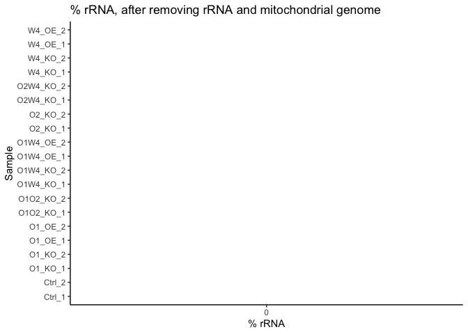

```r
rrna.genes = names(ensembl.genes[ensembl.genes$gene_biotype %in% c("Mt_rRNA", "rRNA",
                                                                   "snoRNA", "snRNA")])

percentage.of.rrna = (colSums(counts(dds_filt[rownames(counts(dds_filt)) %in% rrna.genes])) / colSums(counts(dds_filt))) * 100
percentage.of.rrna = as.data.frame(percentage.of.rrna)
percentage.of.rrna$name = row.names(percentage.of.rrna)
#percentage.of.rrna$name = factor(percentage.of.rrna$name, rev(experimental_metadata$sample_id))


ggplot(percentage.of.rrna, aes(x=name, y=percentage.of.rrna)) +
  geom_bar(stat="identity") + theme_classic() + coord_flip() + scale_y_continuous("% rRNA", expand=c(0,0)) +
  scale_x_discrete("Sample") +
  ggtitle(paste0("% rRNA, ", plt_title))
```

Checking that rRNA percentage is now zero:

```r
summary(percentage.of.rrna$percentage.of.rrna)
```

```
   Min. 1st Qu.  Median    Mean 3rd Qu.    Max.
      0       0       0       0       0       0
```

## 5.2 QC - number of genes

**Size Factors after rRNA removal**

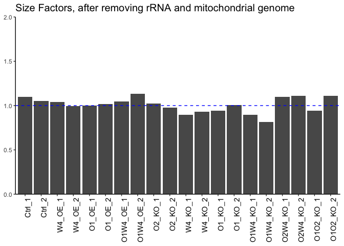

```r
df = data.frame(sample_id = names(sizeFactors(dds_filt)), sizeFactors = sizeFactors(dds_filt))

df$sample_id = factor(df$sample_id, experimental_metadata$sample_id)

ggplot(df, aes(x = sample_id, y=sizeFactors)) +
  geom_bar(stat="identity") +
  scale_y_continuous(limits=c(0,2), expand=c(0,0)) +
  theme_classic() +
  theme(axis.text.x = element_text(angle = 90, hjust=1, colour="black", size=11)) +
  geom_hline(yintercept = 1, color = "blue", linetype = "dashed") +
  ggtitle(paste0("Size Factors, ", plt_title)) +
  th
```

Summary of size factors:

```r
summary(sizeFactors(dds_filt))
```

```
   Min. 1st Qu.  Median    Mean 3rd Qu.    Max.
 0.8131  0.9407  1.0126  1.0061  1.0638  1.1319
```

Size factors for each sample:

```r
print(sizeFactors(dds_filt))
```

```
   Ctrl_1    Ctrl_2   W4_OE_1   W4_OE_2   O1_OE_1   O1_OE_2 O1W4_OE_1 O1W4_OE_2
1.0999289 1.0526837 1.0378320 0.9965829 1.0015226 1.0182475 1.0443977 1.1318862
  O2_KO_1   O2_KO_2   W4_KO_1   W4_KO_2   O1_KO_1   O1_KO_2 O1W4_KO_1 O1W4_KO_2
1.0259569 0.9790215 0.8944856 0.9301420 0.9410265 1.0069593 0.8930973 0.8130668
O2W4_KO_1 O2W4_KO_2 O1O2_KO_1 O1O2_KO_2
1.0970052 1.1114787 0.9395419 1.1077430
```

**Read counts per sample after rRNA and chrM removal**

```r
total_counts <- as.data.frame(colSums(counts(dds_filt)))
colnames(total_counts) <- "total_counts"
total_counts$name = rownames(total_counts)
```

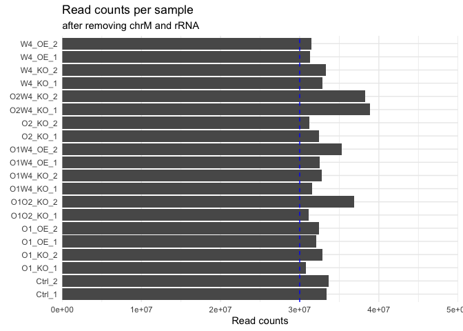

```r
# Plot
ggplot(total_counts, aes(x = name, y = total_counts)) +
    geom_bar(stat = "identity") +
    scale_y_continuous("Read counts",
                       limits = c(0, 5e7),
                       expand = c(0, 0),
                       breaks = seq(0, 5e7, 1e7)) +
    geom_hline(yintercept = 3e7, color = "blue", linetype = "dashed") +
    labs(title = "Read counts per sample",
         subtitle = "after removing chrM and rRNA",
         x = element_blank()) +
    theme_minimal() +
    coord_flip()
```

**Number of genes detected per sample after rRNA and chrM removal**

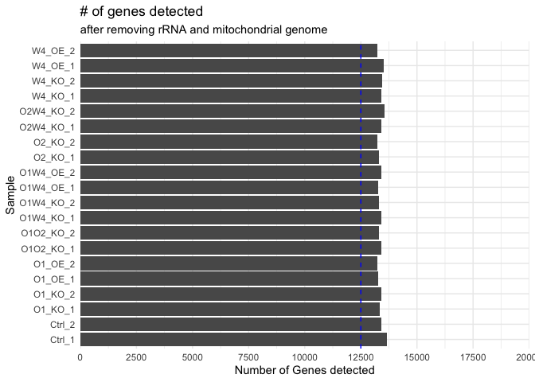

```r
detected = apply(counts(dds_filt), 2, function(col) sum(col > 0 ))
detected = as.data.frame(detected)
detected$name = row.names(detected)
#detected$name = factor(detected$name, rev(experimental_metadata$sample_id))

ggplot(detected, aes(x=name, y=detected)) +
                 geom_bar(stat="identity") +
                 theme_minimal() +
                 coord_flip() +
                 scale_y_continuous("Number of Genes detected",
                                    breaks = c(seq(0, 20000, 2500)),
                                      expand=c(0,0),
                                    limits = c(0, 20000)) +
                 scale_x_discrete("Sample") +
                 labs(title = "# of genes detected",
                     subtitle = plt_title) +
                 geom_hline(yintercept = 12500, color = "blue", linetype = "dashed")
```

## 5.3 QC- clustering

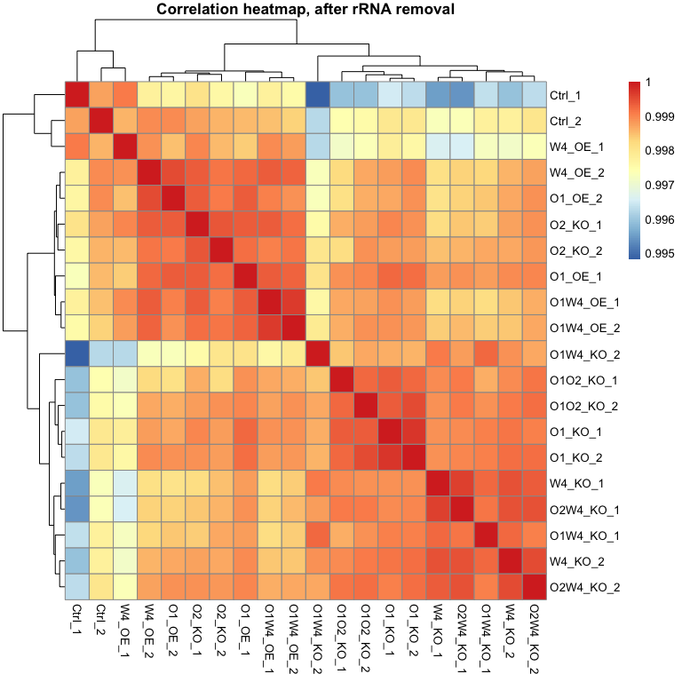

```r
### Extract the vst matrix from the object
rld_mat <- assay(rld_filt)

### Compute pairwise correlation values
rld_cor <- cor(rld_mat)

### Plot heatmap
pheatmap(rld_cor, main = "Correlation heatmap, after rRNA removal")
```

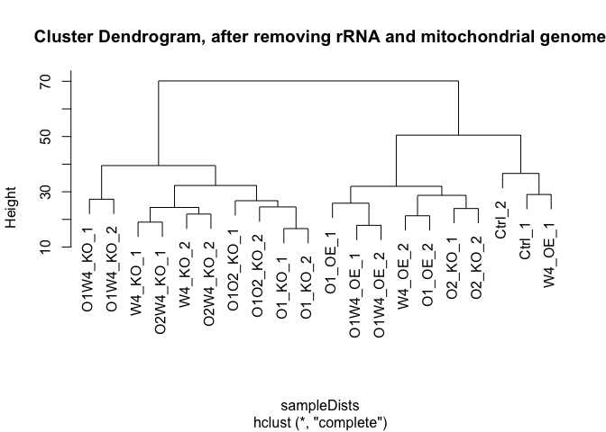

```r
sampleDists <- dist(t(assay(rld_filt)))
plot(hclust(sampleDists), main = paste0("Cluster Dendrogram, ", plt_title))
```

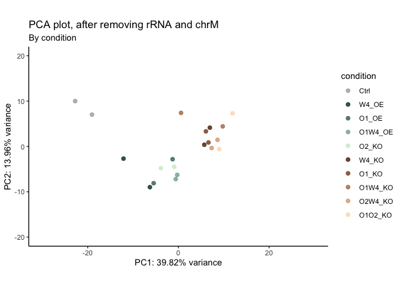

```r
pca_rmrna <- make_pca(rld_filt, intgroup = "condition",
         title = "PCA plot, after removing rRNA and chrM",
         xlimits = pca_xlim,
         ylimits = pca_ylim,
         manual_colors = col_colors,
         rearrange_intgroup = TRUE,
         intgroup_order = intgroup_order)
pca_rmrna
```

```r
# Save this
saveRDS(rld_filt, file = paste0(output_dir, "rld_filt.RDS"))
saveRDS(pca_rmrna, file = paste0(output_dir, "pca_rmrna.RDS"))
```

**PCA, labelled**

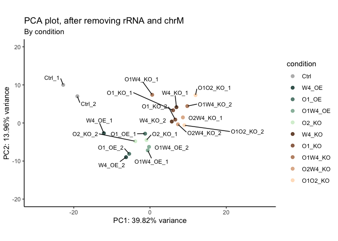

```r
pca_rmrna_label <- make_pca(rld_filt, intgroup = "condition", label = TRUE,
         title = "PCA plot, after removing rRNA and chrM",
         xlimits = pca_xlim,
         ylimits = pca_ylim,
         manual_colors = col_colors,
         rearrange_intgroup = TRUE,
         intgroup_order = intgroup_order)
pca_rmrna_label
```

```r
# Save this

saveRDS(pca_rmrna_label, file = paste0(output_dir, "pca_rmrna_label.RDS"))
```

**PCA, by size factor**

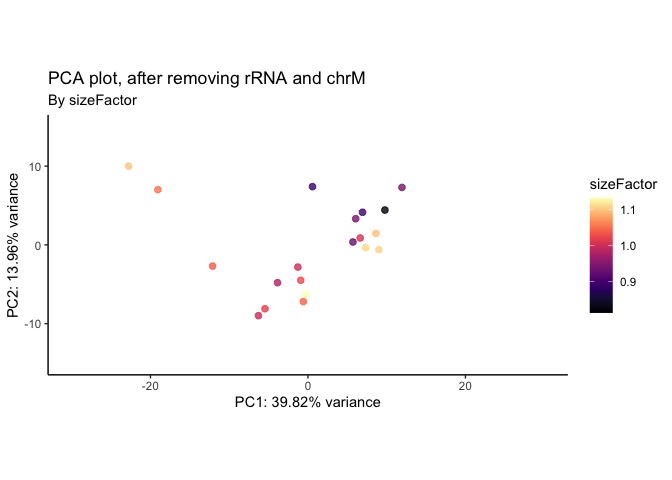

```r
make_pca(rld_filt, intgroup = "sizeFactor",
         title = "PCA plot, after removing rRNA and chrM") +
  scale_color_viridis(option = "A")
```

# 6 Check Wnt4, Otk1 and Otk2 levels

## 6.1 Otk1 counts

We plot the normalized counts of Otk1 in each sample:

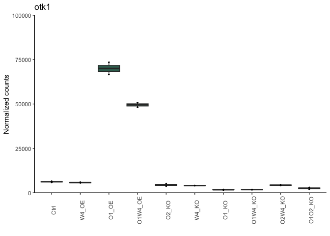

```r
otk1_fbgn <- "FBgn0004839"

# Get normalized counts
otk1_norm <- as.data.frame(counts(dds_filt, normalized = TRUE)[otk1_fbgn, ])
otk1_norm$sample <- rownames(otk1_norm)
colnames(otk1_norm) <- c("counts", "sample")
otk1_norm$sample = factor(otk1_norm$sample,
                          levels = experimental_metadata$sample_id)
otk1_norm$condition = otk1_norm$sample
otk1_norm$condition = gsub("_[0-9]", "", otk1_norm$condition)
otk1_norm$condition = factor(otk1_norm$condition,
                             levels = unique(experimental_metadata$condition))

write.csv(otk1_norm, file = paste0(output_dir, "otk1_norm_counts.csv"))

# Plot
otk1_plot <- ggplot(otk1_norm, aes(x = condition, y = counts, fill = condition)) +
  geom_boxplot() +
  geom_point(size = 0.5) +
  labs(title = "otk1",
       x = "", y = "Normalized counts") +
  scale_fill_manual(values = col_colors) +
  scale_y_continuous(expand = c(0, NA), limits = c(0, 1e5)) +
  theme_classic() +
  theme(axis.text.x = element_text(angle = 90),
        legend.position = "none")

otk1_plot
```

```r
saveRDS(otk1_plot, file = paste0(output_dir, "otk1_plot.RDS"))
```

## 6.2 Otk2 counts

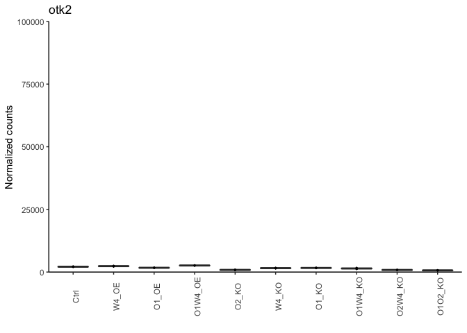

```r
otk2_fbgn <- "FBgn0267728"

# Get normalized counts
otk2_norm <- as.data.frame(counts(dds_filt, normalized = TRUE)[otk2_fbgn, ])
otk2_norm$sample <- rownames(otk2_norm)
colnames(otk2_norm) <- c("counts", "sample")
otk2_norm$sample = factor(otk2_norm$sample,
                          levels = experimental_metadata$sample_id)
otk2_norm$condition = otk2_norm$sample
otk2_norm$condition = gsub("_[0-9]", "", otk2_norm$condition)
otk2_norm$condition = factor(otk2_norm$condition,
                             levels = unique(experimental_metadata$condition))

write.csv(otk2_norm, file = paste0(output_dir, "otk2_norm_counts.csv"))

# Plot
otk2_plot <- ggplot(otk2_norm, aes(x = condition, y = counts, fill = condition)) +
  geom_boxplot() +
  geom_point(size = 0.5) +
  labs(title = "otk2",
       x = "", y = "Normalized counts") +
  scale_fill_manual(values = col_colors) +
  scale_color_manual(values = col_colors) +
  scale_y_continuous(expand = c(0, NA), limits = c(0, 1e5)) +
  theme_classic() +
  theme(axis.text.x = element_text(angle = 90),
        legend.position = "none")

otk2_plot
```

```r
saveRDS(otk2_plot, file = paste0(output_dir, "otk2_plot.RDS"))
```

## 6.3 Wnt4 counts

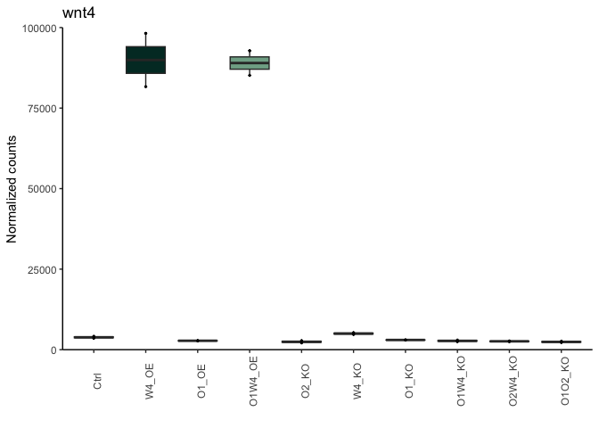

```r
wnt4_fbgn <- "FBgn0010453"

# Get normalized counts
wnt4_norm <- as.data.frame(counts(dds_filt, normalized = TRUE)[wnt4_fbgn, ])
wnt4_norm$sample <- rownames(wnt4_norm)
colnames(wnt4_norm) <- c("counts", "sample")
wnt4_norm$sample = factor(wnt4_norm$sample,
                          levels = experimental_metadata$sample_id)
wnt4_norm$condition = wnt4_norm$sample
wnt4_norm$condition = gsub("_[0-9]", "", wnt4_norm$condition)
wnt4_norm$condition = factor(wnt4_norm$condition,
                             levels = unique(experimental_metadata$condition))

write.csv(wnt4_norm, file = paste0(output_dir, "wnt4_norm_counts.csv"))

# Plot
wnt4_plot <- ggplot(wnt4_norm, aes(x = condition, y = counts, fill = condition)) +
  geom_boxplot() +
  geom_point(size = 0.5) +
  labs(title = "wnt4",
       x = "", y = "Normalized counts") +
  scale_fill_manual(values = col_colors) +
  scale_y_continuous(expand = c(0, NA), limits = c(0, 1e5)) +
  theme_classic() +
  theme(axis.text.x = element_text(angle = 90),
        legend.position = "none")


wnt4_plot
```

```r
saveRDS(wnt4_plot, file = paste0(output_dir, "wnt4_plot.RDS"))
```